# 20 a 26 Set:

### 1- Leitura da Bibliografia, com foco para já na modelação

### 2- Implementação em Matlab/Simulink do modelo da sistema Mesa Sísmica + Modelo 2DOF (M, K, C) da estrutura em teste

### 3- Implementação em Matlab/Simulink do método de geração do drive da mesa sísmica utilizado atualmente, conforme Doc MTS 'How To Use Online Iteration (OLI)'

### tarefa 3 por fazer

## Papers/Teses:

### 1- tese 2021 PhD_Gidewon_Tekeste RTHT.pdf

```
cap 2.8 - Estratégia de controlo
cap 3.3 - Modelo Mesa Sísmica
```

2021 PhD_Gidewon_Tekeste RTHT

RTHS GidewonGTekeste presentation

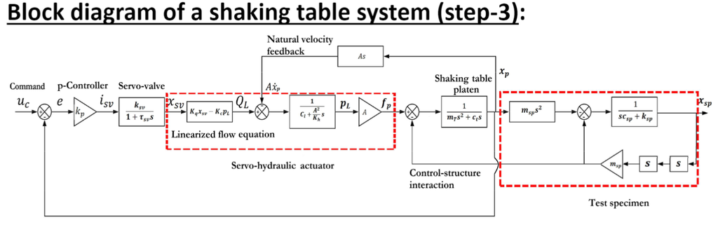

### 2-paper Wiliams & Blakeborough 2001

```
cap 2 - Estartegias de controlo mesa sísmica
```

2001_PTRSLa_MS Williams_A Blakeborough_Dynamic testing overview

### 3- paper Benchmark control problem for real-time hybrid simulation 2019

```
cap 4.2 - modelos
```

2019BenchmarckControlProblemRTHS

### 4-Phillips, B., & Spencer, B. (2011) Model-Based Servo-Hydraulic Control for Real-Time Hybrid Simulation. University of Illinois at Urbana-Champaign: NSEL Report Series., June2011

```
Cap 2 - Modelo
Cap 3 - Controlo
Cap 4.2 - Identificação/caracterização
```

https://www.ideals.illinois.edu/items/26148/bitstreams/89422/data.pdf

NSEL_Report_28_final

### 5- Carrion, J., & Spencer, B. (2007) Model-based Strategies for Real-time Hybrid Testing. University of Illinois at Urbana-Champaign:NSEL Report Series., December.

```
Cap 6 - descrição Servo-valvula e modelação
Cap 7 - controlo
```

https://core.ac.uk/download/pdf/4813726.pdf

Carrion & Spencer 2007.pdf

### 6-Paper Cascade Control Method for Conducting Hybrid Simulation with Stiff Specimens

```
estrategia controlo desloc + força
```

WCEE2024-You_etal_presentation CascadeControl

### 7- MODELING OF THE NHERI UCSD 6-DOF OUTDOOR SHAKE TABLE UNDER BARE TABLE AND LOADEDCONDITIONS,C. Lai & J. Conte

```
plataforma sísmica
```

WCEE2024-Lai_Conte_presentation

WCEE2024-Lai_Conte

### 8- paper FUTURE PERSPECTIVE OF CONTRIBUTION TO RESEARCH ON EARTHQUAKE-DISASTER RISK REDUCTION WITH E-DEFENSE, K. Tabata1, Y. Kawamata2, Y. Komatsu2, E. Sato2, J. Fujiwara2, T. Yamashita1 & Y. Nakano1,3

```
plataforma sísmica Japão
```

WCEE2024-Tabata_etal

### 9- paper EUROPEAN LABORATORY FOR STRUCTURAL ASSESSMENT: 30 YEARS OF COLLABORATIVE RESEARCH, G. Tsionis1 , P. Negro2, J. Molina2, M. Peroni2, M. Lamperti Tornaghi2 & P. Pegon3

```
plataforma sismica ESLA
```

WCEE2024-Tsionis_etal_presentation

WCEE2024-Tsionis_etal

### 10- paper AN ULTIMATE CHOICE BETWEEN SHAKING TABLE TEST AND HYBRID SIMULATION FOR ADVANCING SEISMIC ANALYSIS AND DESIGN , Masayoshi Nakashima

```
comparação métodos ensaio
```

WCEE2024-Nakashima_etal_presentation

WCEE2024-Nakashima_etal

### 11-Estrategias Controlo MTS

Pasta com doc técnicos com descrição das várias estrategias da MTS

MTSstrategies

### 12 - tese MSC Joao Marques

```
descricao/modelacao Plat Sismica LNEC
descricao metodos identificacao
```

2016_MSC_JoaoMarquesTFM

### 13 - docuemnto 'NotesOnServoController(FCarvalhal)'

```
estrategias de controlo PID e AAF
```

NotesOnServoController(FCarvalhal).pdf)

### 14 - tese F.Oliveira Modelo MKC 1DOF, 2DOF e 10DOF

```
Estratégias de controlo (semi-ativo)
```

PhD_Thesis_Foliveira

Envio-te o documento com a descrição do processo dos ensaios sísmicos no LNEC e dois artigos sobre ensaios sísimicos, e em particular os ensaios em mesa sismica. Um dos artigos vai em anexo e o outro como está publicado num livro (pg 173) vai por wetransfer. Os artigos cotêm informação de cariz geral para perceberes as técnicas de ensaio com foco na semelhança fisica modelo-protótipo devido ao efeito de escala. São uteis para fazeres a revisão do estado da arte.

### 15 - EnsaiosSismicosLNEC.docx

EnsaiosSismicosLNEC

### 16- 1998 paper_Seismic testing of structures

1998 paper_Seismic testing of structures

### 17- 2023_AdvancesOnTenting&ExpCivilEngineering (página 173)

2023_AdvancesOnTenting&ExpCivilEngineering

# 27/9 a 3 de Outubro:

### 1-Avaliar a possibilidade de considerar para trabalho da cadeira de Sistemas Inteligentes a tarefa de modelação da estrutura em teste nos ensaios sísmicos com recurso a redes neuronais, utilizando as séries temporais de aceleração medidas (entrada na plataforma sísmica e saídas ao nível dos pisos) da estrutura exposta a um sismo; esta tarefa terá bastante interesse para a tese visto que poderá dar um contributo na modelação da estrutura em teste, modelo que é necessário para sintetizar o melhor controlador;

- Consultei responsavel da UC e está aprovado há partida.
- A aguardar que o Fernando forneça dados.
- Escrever e entregar proposta.

### 2-Obter as séries temporais dos sismos em termos de velocidade e deslocamento a partir das séries fornecidas em aceleração (m/s^2); usar as funções Matlab/Simulink disponibilizadas, adaptá-las ou construir outras; observar resultados e concluir quanto ao comportamento das séries, seus limites – comparar com limites da plataforma sísmica; corrigir eventuais derivas das séries obtidas;

- Não percebi porque é que é necessário corrigir a "deriva". **Perguntar**

### 3.1- Construir modelo matemático do sistema mesa sísmica (tese Gidewon, pg.87)

**Perguntar**

- Há parametros em falta:
  - $k_c$ , Valve pressure flow gain
  - $C_L$ , Total leakage coefficient of the piston

  No Gidewon vem que $k_{pl} = k_c + C_L$ portanto assumi $k_c = C_L = \frac{k_{pl}}{2}$
- Converter todas os parametros em unidades SI

### 3.2- Construir modelo 2DOF (exemplo tese FO, pg 147; matriz C tem de ser modificada para que c_s ligue da massa m_i a m_s) em Matlab/Simulink; proponho como parâmetros para modelar m_i=m_s=2000kg; ajustar k_i, k_s, c_i e c_s para obter as frequências naturais e amortecimentos dos modos pretendidos;

- Usar $f_1$=2Hz, $ξ_1$=5%, $f_2$=8Hz, $ξ_2$=10%,

### 4-Com um modelo de referência, $f_1$=2Hz, $ξ_1$=5%, $f_2$=8Hz, $ξ_2$=10%, fechar o anel com um controlador PID e projetar o controlador PID: P, PI, PD ou PID; avaliar qual o mais adequado ao presente caso;

### 5-Simular o modelo com algumas ações sísmicas (pelo menos 3) em deslocamento (obtidas de 1) e comparar referência com saída em termos de resposta no tempo; observar resultados e avaliar diferenças;

### 6-Fazer comparação entre a referência e a saída em termos de espetro de resposta; utilizar função Matlab/Simulink ’ResponseSpectra’ disponibilizadas adaptá-las ou construir outras para fazer a comparação; observar resultados e avaliar diferenças;

# 4/10 a 16/10:

### 1 - Relativamente à simplificação do diagrama blocos por forma a chegar a uma configuração que permita utilizar os parâmetros disponíveis, dou-te a seguinte dica: a partir das funções de transferência dos blocos, escrever a equação da pressão em função dos parâmetros e das entradas/retroações, i.e. p_l=f(parametros, x_p, i_sv). Se tiveres dúvidas diz!

### 2 - No que concerne aos dados experimentais, já os encontrei e envio-os no link abaixo (Wetransfer). Envio os dados dos ensaios com sistema de 2DOF (duas massas e molas a ligar à plataforma sísmica) com um amortecedor Magneto-Reológico no modo passivo ligado entre a plataforma e a massa 1 (com 0, 1, 2, 3, 4, 5 Volts, que lhe dão diferentes dissipações de energia), exposta aos vários sismos indicados (10 ações tipo1 do EC8, 10 ações tipo 2 do EC8 e 7 sismos diferentes). A descrição do sistema está no cap.4 da minha tese PhD, pg 149. Proponho que se escolham os dados referentes à tensão eléctrica 1Volt do amortcedor. Tens os dados das grandezas aceleração e deslocamento relativo conforme descrito na pg. 147 da tese e nos files matlab (CompararResultados.m; este script em particular permite visualizar os dados bastando mudar o nomo do file). Deves fezer uma análise prévia aos resultados e decidir quanto à sua qualidade, i.e. são dados experimentais e têm associados ruído eléctrico, eventuais offsets na aceleração, etc. que deverão ser avaliados para eventual tratamento prévio antes de os utilizar. Penso que deves aprender/abordar isso com o Professor da cadeira, pois como já falámos nas nossas reuniões, a construção de um bom modelo dependerá da qualidade dos dados utilizados. Se tiveres dúvidas quanto à interpretação dos dados avisa.

Link Wetransfer: https://we.tl/t-qp18kjkAST

# 17/10 a 24/10:

### Pasta "AnaliseAcoes", o scrip 'EspetroResposta18102024.m' irá permitir-te carregar o sismo com a função 'load sismo.txt', e no final tens a funcao 'ResponseSpectra()' que te permite visualizar o espetro de resposta e gravar. O file gravado pode depois ser visualizado conforme está no final do script. Está ainda um passo intermedio com a funcao 'Integra()' que te permite visualizar os deslocamentos, velocidades e aceleracoes (que podes ou não correr).